# Sinangoe vs. Zabalo

Morgan Manning

2023-11-10

# Sinangoe versus Zabalo

## Timeframe

In Zabalo, camera trapping commenced on 2018-07-03 and ended on 2018-10-09, spanning 98 days. As for Sinangoe, trapping began on 2022-08-02 and ended on 2022-12-01, going for 121 days.

## Consolidating time steps

### Sinangoe

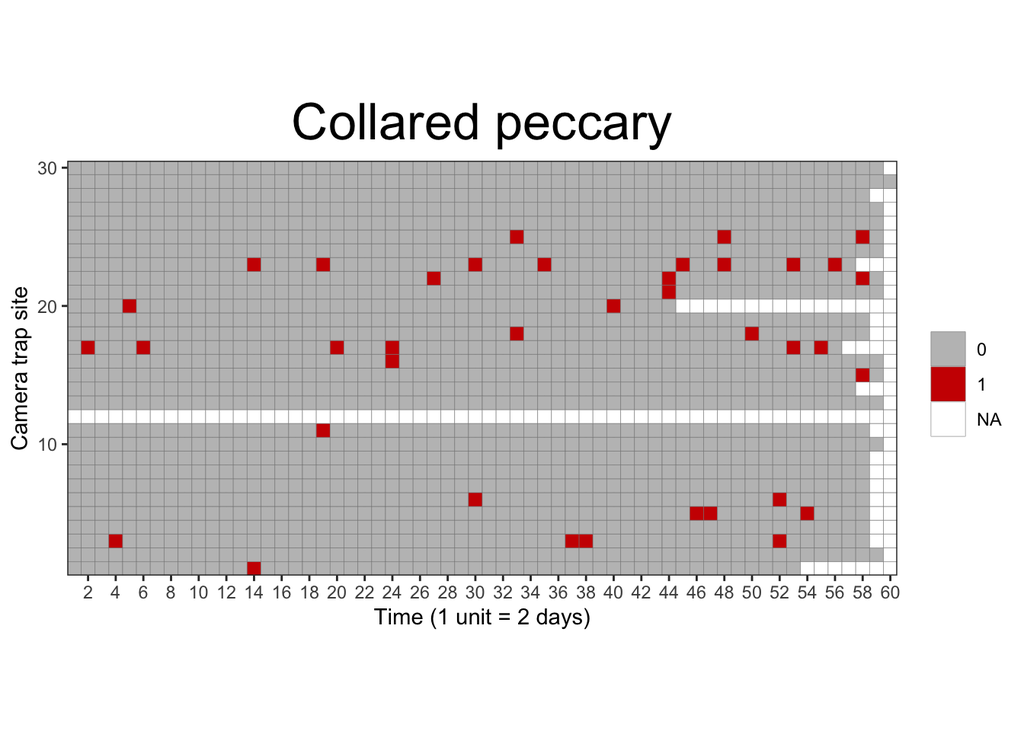

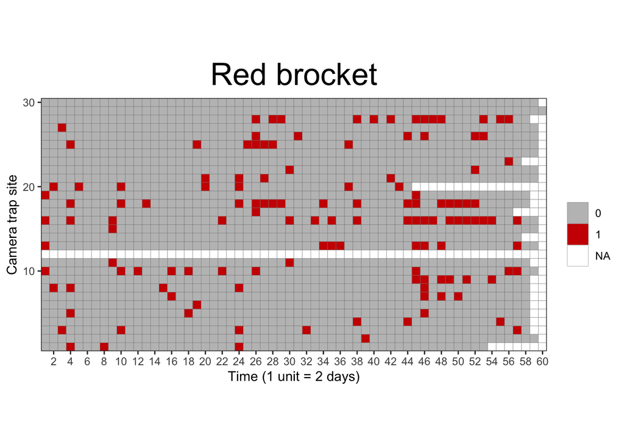

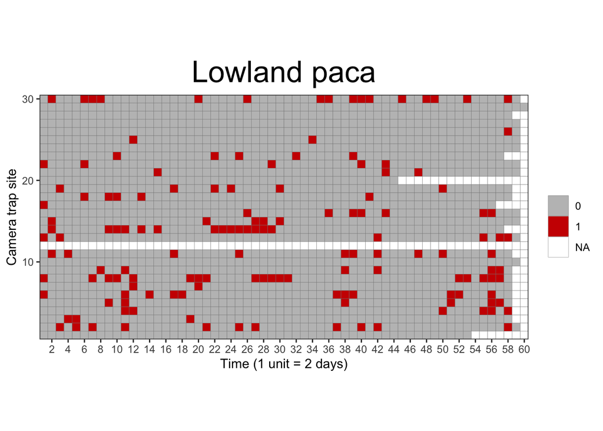

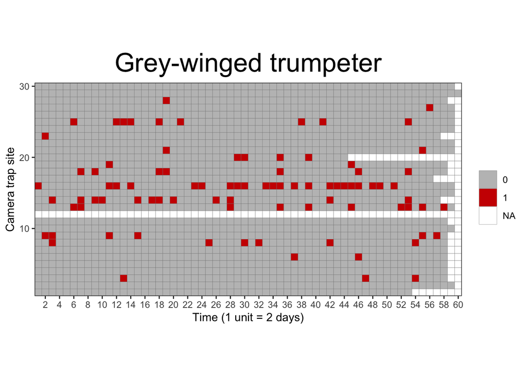

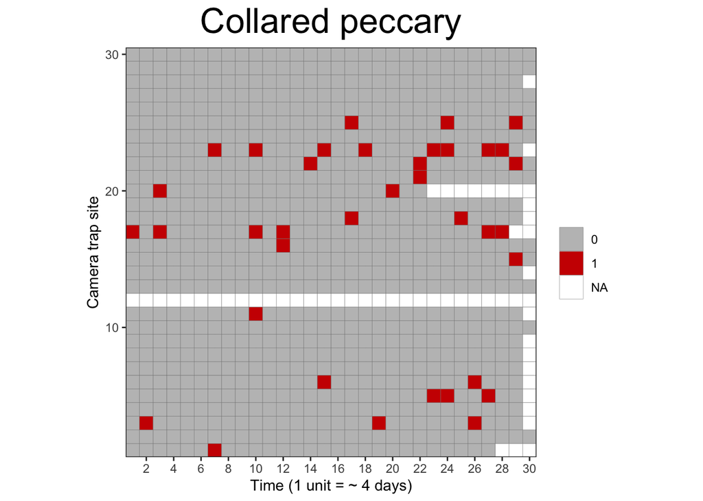

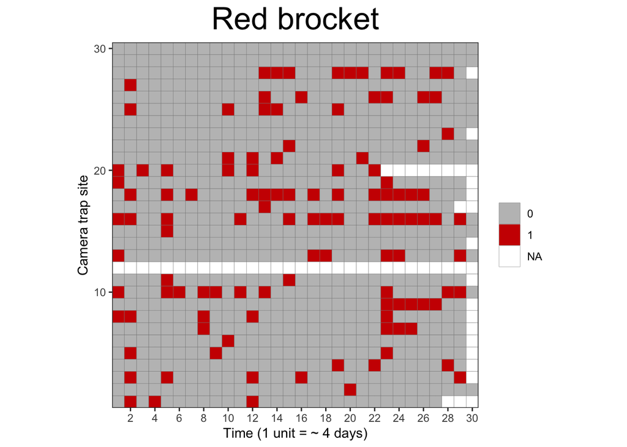

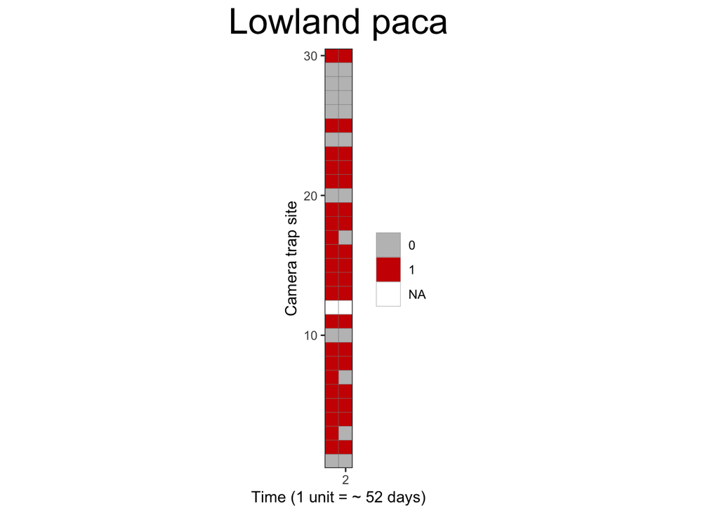

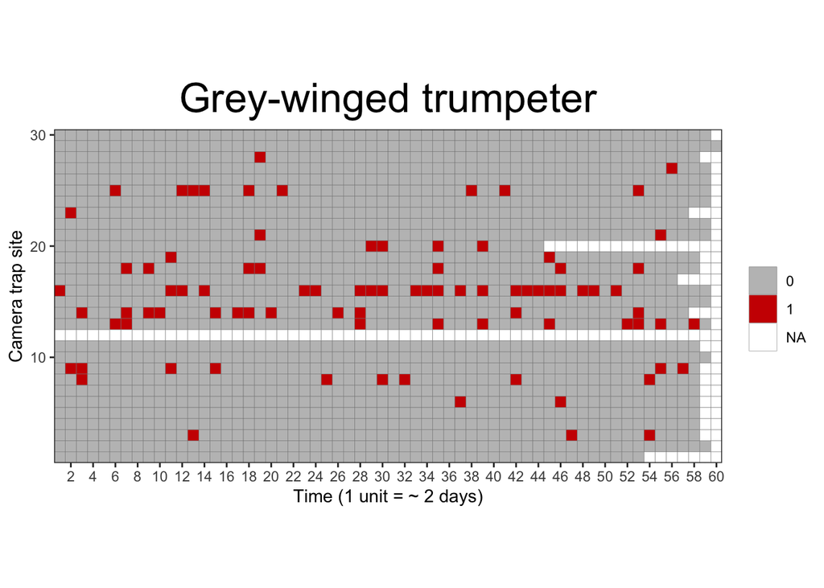

### Zabalo

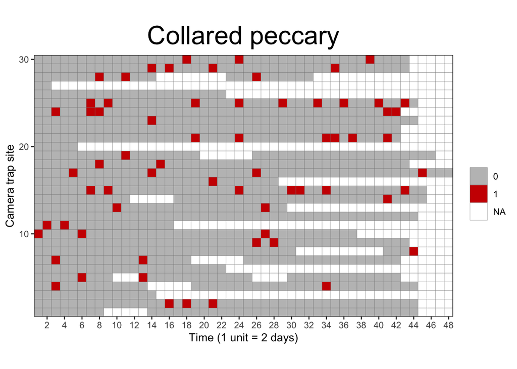

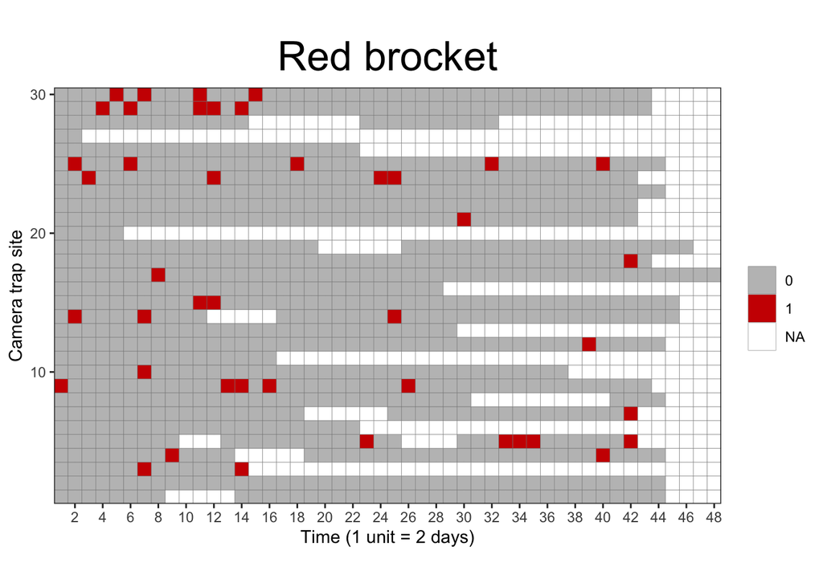

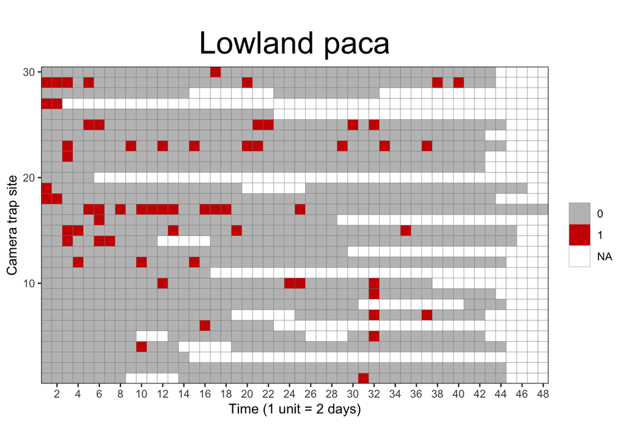

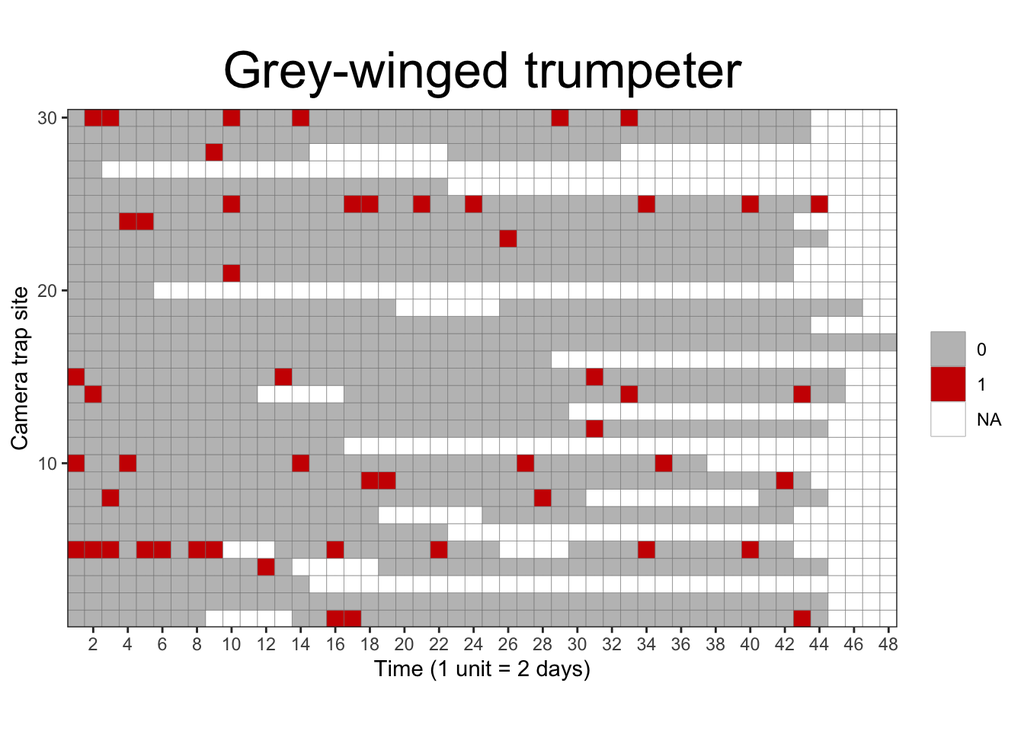

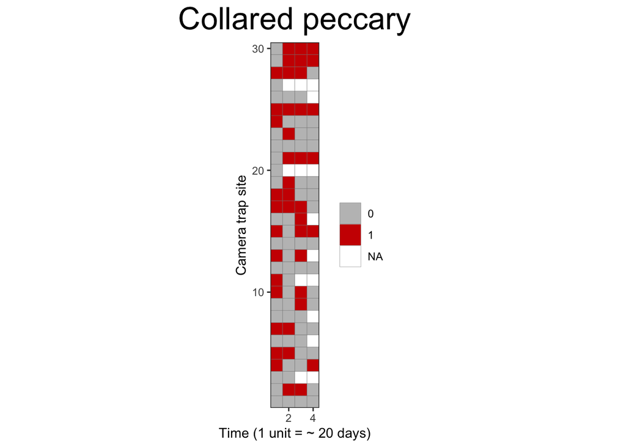

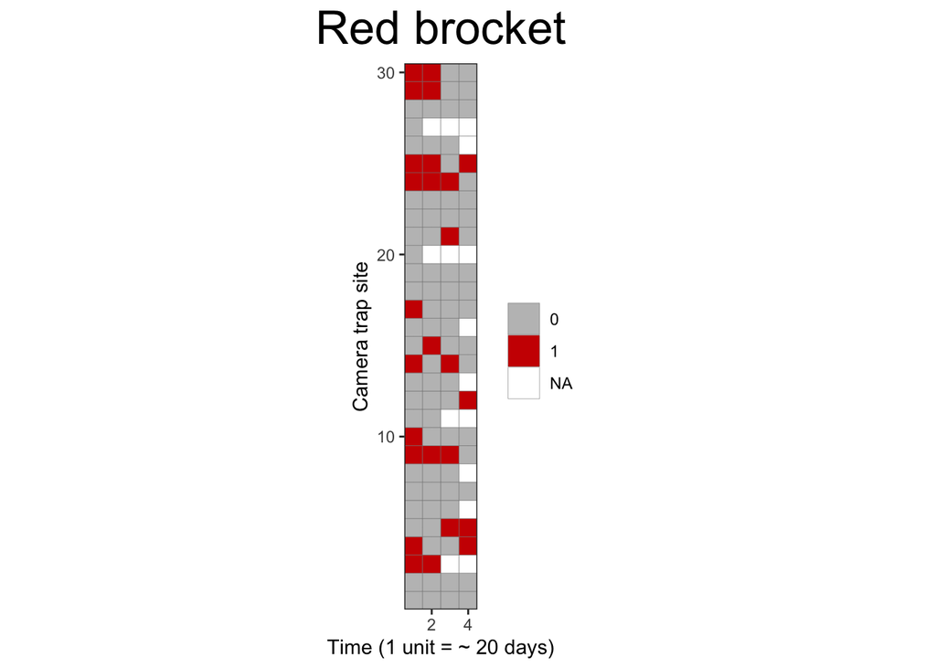

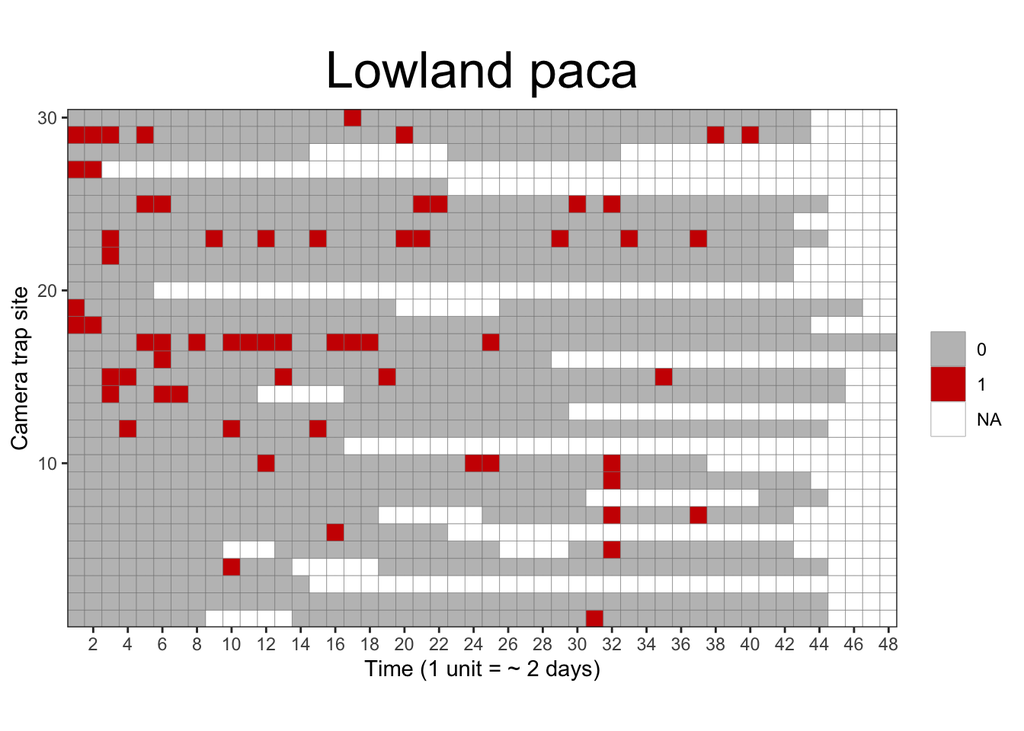

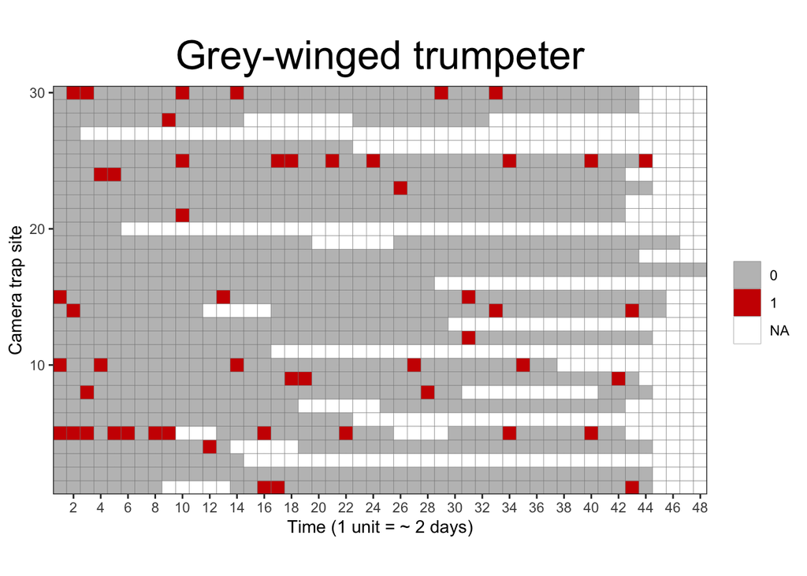

## Top species

### Zabalo

Zabalo Species

|  | Species | Total |
| --- | --- | --- |
| 4 | Cuniculus paca | 79 |
| 7 | Dicotyles tajacu | 78 |
| 14 | Mazama gouazoubira | 72 |
| 25 | Psophia crepitans | 59 |
| 5 | Dasyprocta fuliginosa | 56 |
| 13 | Mazama americana | 48 |
| 30 | Tayassu pecari | 42 |
| 1 | Atelocynus microtis | 40 |
| 15 | Mitu salvini | 32 |
| 29 | Tapirus terrestris | 32 |
| 6 | Dasypus novemcinctus | 22 |
| 18 | NA NA | 20 |
| 9 | Eira barbara | 15 |
| 3 | Crypturellus undulatus | 12 |
| 17 | Myrmecophaga tridactyla | 12 |

### Sinangoe

Sinangoe Species

|  | Species | Total |
| --- | --- | --- |
| 23 | N/D N/D | 854 |
| 20 | Metachirus nudicaudatus | 371 |
| 8 | Dasyprocta fuliginosa | 312 |
| 7 | Cuniculus paca | 171 |
| 19 | Mazama americana | 156 |
| 28 | Philander andersoni | 136 |
| 9 | Dasypus novemcinctus | 135 |
| 13 | Geotrygon montana | 132 |
| 39 | Tinamus major | 110 |
| 11 | Didelphis marsupialis | 107 |
| 34 | Psophia crepitans | 103 |
| 24 | Nasua nasua | 52 |
| 25 | Nothocrax urumutum | 52 |
| 10 | Dicotyles tajacu | 45 |
| 15 | Hadrosciurus spadiceus | 39 |

## Occupancy modeling

Proceeding with all models for Sinangoe and models without missing estimates or disproportionately large standard errors for Zabalo.

### Zabalo

Collared peccary

|  | ModelName | AIC | diffFromBest |
| --- | --- | --- | --- |
| 7 | ~1 ~ 1 | 140.4282 | 0.000000 |
| 2 | ~1 ~ Trail.Distance | 142.1786 | 1.750435 |
| 3 | ~1 ~ HuntingIntensity | 142.2508 | 1.822676 |

Red brocket

|  | ModelName | AIC | diffFromBest |
| --- | --- | --- | --- |
| 4 | ~Effort + Habitat ~ 1 | 112.9465 | 0.000000 |
| 1 | ~Effort + Habitat ~ Trail.Distance | 114.0893 | 1.142761 |
| 2 | ~Effort + Habitat ~ HuntingIntensity | 114.4834 | 1.536911 |

Lowland paca

|  | ModelName | AIC | diffFromBest |
| --- | --- | --- | --- |
| 8 | ~Effort + Habitat ~ 1 | 466.9433 | 0.000000 |
| 2 | ~Effort + Habitat ~ Trail.Distance | 468.1459 | 1.202603 |
| 5 | ~Effort + Habitat ~ Habitat + HuntingIntensity | 468.5897 | 1.646409 |
| 3 | ~Effort + Habitat ~ HuntingIntensity | 468.8361 | 1.892793 |

Grey-winged trumpeter

|  | ModelName | AIC | diffFromBest |
| --- | --- | --- | --- |
| 2 | ~Effort ~ Trail.Distance + HuntingIntensity | 379.2717 | 0.000000 |
| 1 | ~Effort ~ HuntingIntensity | 380.6071 | 1.335412 |

#### Top Models

##### Collared peccary

```
## Occupancy:
##  Estimate    SE    z P(>|z|)
##      1.26 0.596 2.12  0.0343
##
## Detection:
##  Estimate    SE      z P(>|z|)
##   0.00419 0.261 0.0161   0.987
```

##### Red brocket

```
## Occupancy:
##  Estimate    SE    z P(>|z|)
##     0.835 0.647 1.29   0.197
##
## Detection:
##               Estimate    SE      z P(>|z|)
## (Intercept)     0.0981 0.899  0.109  0.9131
## Effort          0.8442 0.361  2.340  0.0193
## HabitatSwamp    0.5960 1.186  0.502  0.6154
## HabitatUpland  -1.3321 1.000 -1.332  0.1827
```

##### Lowland paca

```
## Occupancy:
##  Estimate   SE    z P(>|z|)
##       1.3 0.56 2.32  0.0205
##
## Detection:
##               Estimate    SE      z  P(>|z|)
## (Intercept)     -1.840 0.234 -7.863 3.74e-15
## Effort           0.103 0.178  0.580 5.62e-01
## HabitatSwamp    -0.680 0.828 -0.821 4.12e-01
## HabitatUpland   -0.933 0.312 -2.993 2.76e-03
```

##### Grey-winged trumpeter

```
## Occupancy:
##                  Estimate    SE    z P(>|z|)
## (Intercept)         0.764 0.641 1.19  0.2332
## Trail.Distance      1.170 0.711 1.65  0.0997
## HuntingIntensity    2.354 1.184 1.99  0.0468
##
## Detection:
##             Estimate    SE      z  P(>|z|)
## (Intercept)    -2.39 0.154 -15.48 4.48e-54
## Effort         -0.47 0.186  -2.53 1.13e-02
```

### Sinangoe

Collared peccary

|  | ModelName | AIC | diffFromBest |
| --- | --- | --- | --- |
| 2 | ~1 ~ 1 | 289.1430 | 0.000000 |
| 1 | ~1 ~ DistToComm | 291.0196 | 1.876652 |

Red brocket

|  | ModelName | AIC | diffFromBest |
| --- | --- | --- | --- |
| 2 | ~1 ~ 1 | 667.8246 | 0.000000 |
| 1 | ~1 ~ DistToComm | 669.4884 | 1.663769 |

Lowland paca

|  | ModelName | AIC | diffFromBest |
| --- | --- | --- | --- |
| 2 | ~1 ~ 1 | 59.54592 | 0.000000 |
| 1 | ~1 ~ DistToComm | 61.43766 | 1.891741 |

Grey-winged trumpeter

| ModelName | AIC | diffFromBest |
| --- | --- | --- |
| ~1 ~ DistToComm | 606.6556 | 0 |

#### Top Models

##### Collared peccary

```
## Occupancy:
##  Estimate    SE     z P(>|z|)
##    0.0799 0.408 0.196   0.845
##
## Detection:
##  Estimate    SE     z P(>|z|)
##     -2.37 0.194 -12.2 3.6e-34
```

##### Red brocket

```
## Occupancy:
##  Estimate    SE    z  P(>|z|)
##      1.87 0.558 3.36 0.000791
##
## Detection:
##  Estimate    SE     z  P(>|z|)
##     -1.65 0.103 -16.1 1.49e-58
```

##### Lowland paca

```
## Occupancy:
##  Estimate    SE    z P(>|z|)
##     0.987 0.423 2.33  0.0196
##
## Detection:
##  Estimate    SE    z  P(>|z|)
##      2.48 0.624 3.98 6.76e-05
```

##### Grey-winged trumpeter

```
## Occupancy:
##             Estimate    SE     z P(>|z|)
## (Intercept)    0.174 0.429 0.405  0.6853
## DistToComm     1.322 0.622 2.125  0.0335
##
## Detection:
##  Estimate    SE     z  P(>|z|)
##     -2.17 0.113 -19.2 4.87e-82
```

## Diversity and richness

#### Diversity

Among Sinangoe stations, the Shannon Diversity Index ranged from 0.305 to 2.589. Among Zabalo stations, the Shannon Diversity Index ranged from 0 to 2.73. Among Siona stations, the Shannon Diversity Index ranged from 0 to 2.548. Among Siekopai stations, the Shannon Diversity Index ranged from 0.349 to 2.269.

Species Diversity

| Community | nIndiv | nSpecies | shannonIndex | simpsonIndex |
| --- | --- | --- | --- | --- |
| Siekopai | 3201 | 44 | 2.232914 | 0.7679467 |
| Sinangoe | 2127 | 38 | 2.773124 | 0.9138674 |
| Siona | 762 | 35 | 2.529869 | 0.8475658 |
| Zabalo | 681 | 29 | 2.856870 | 0.9278184 |

## Occupancy predictions

### Sinangoe

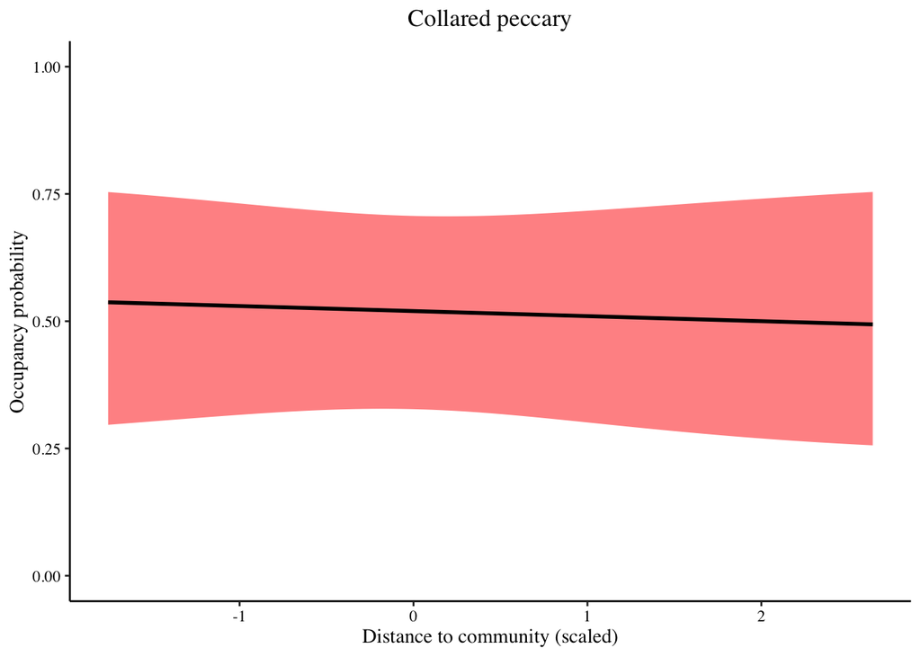

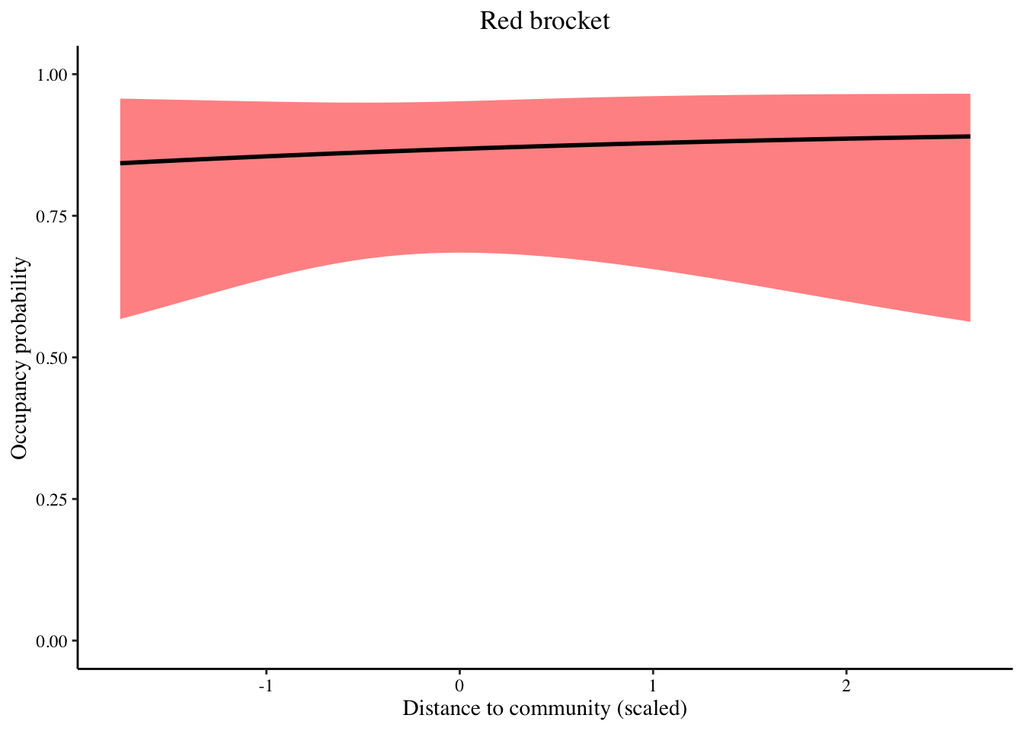

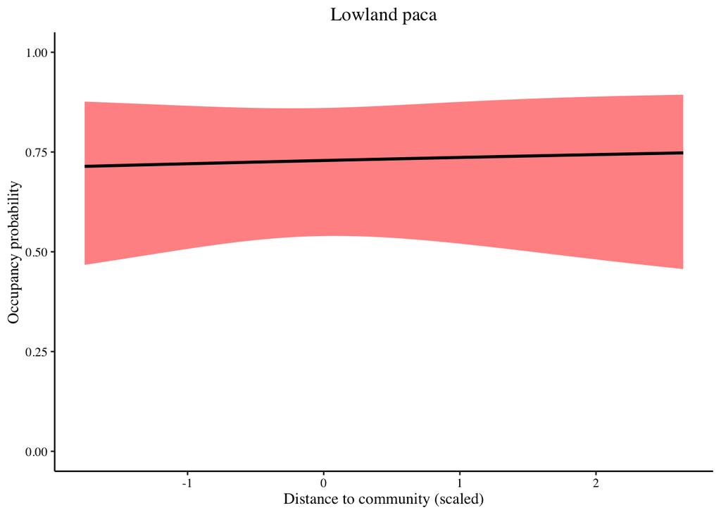

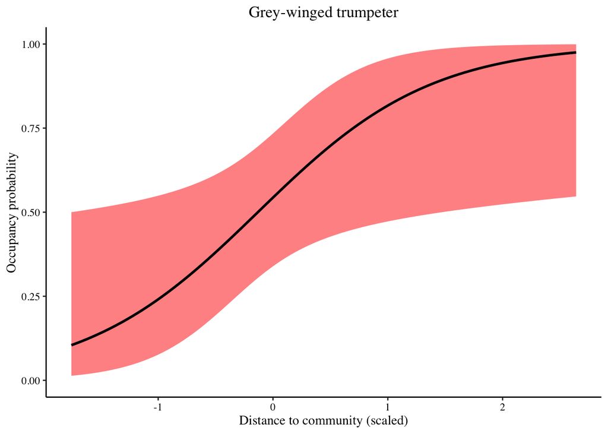

### Zabalo

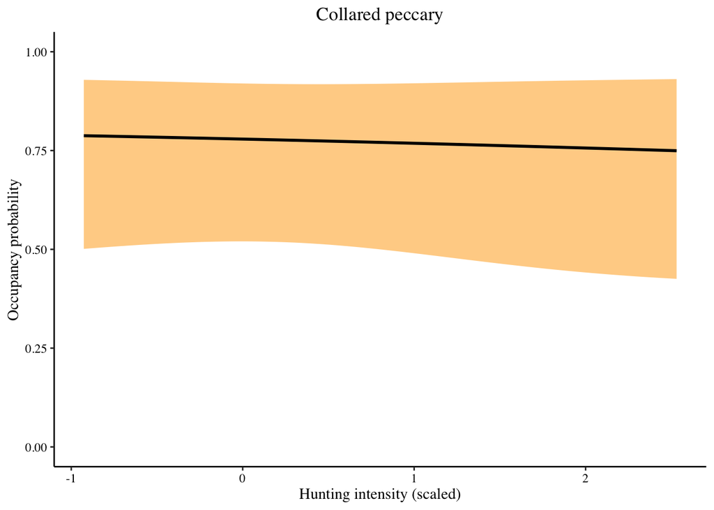

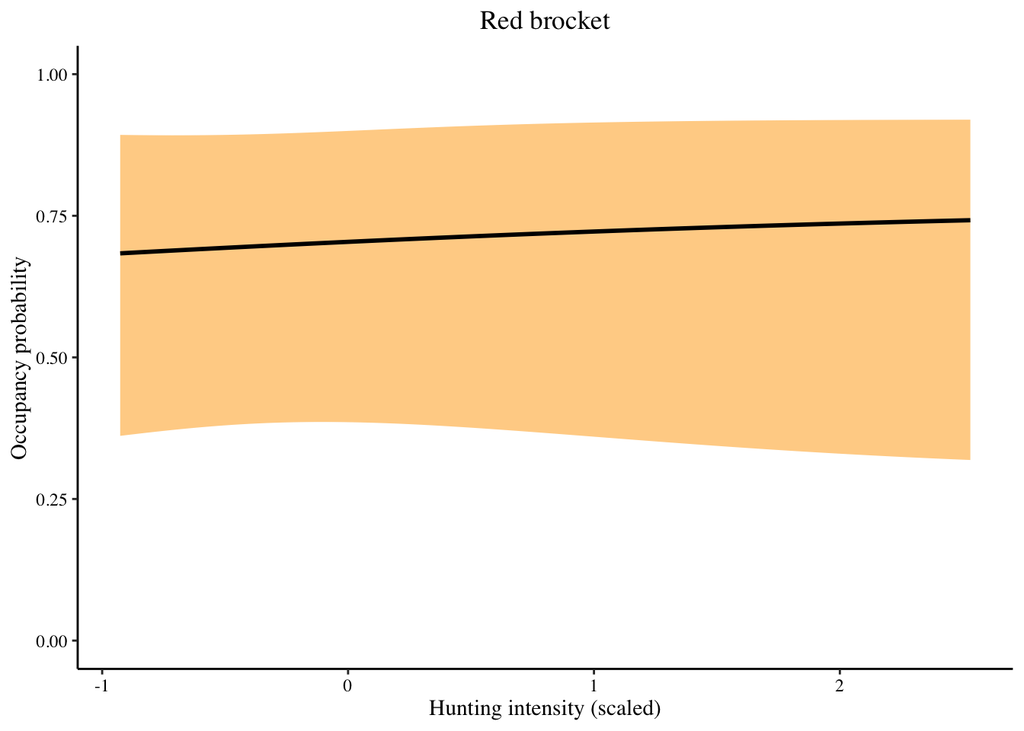

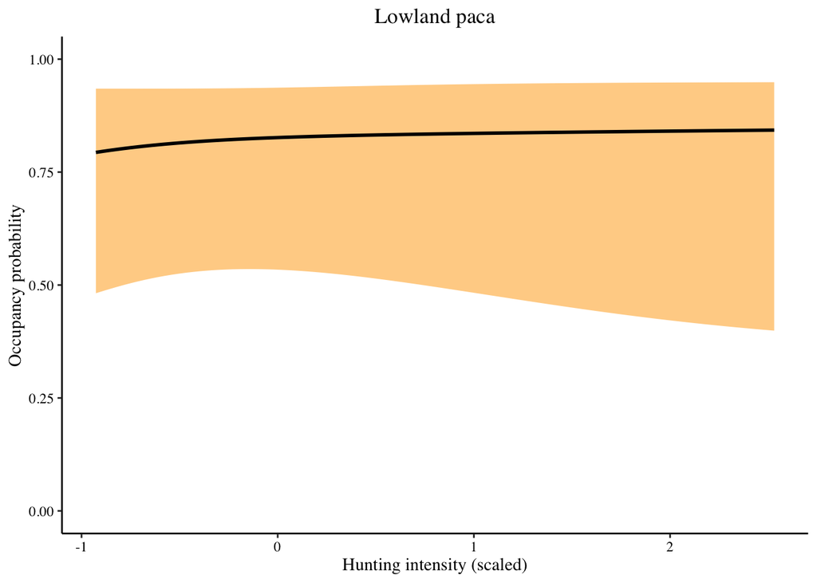

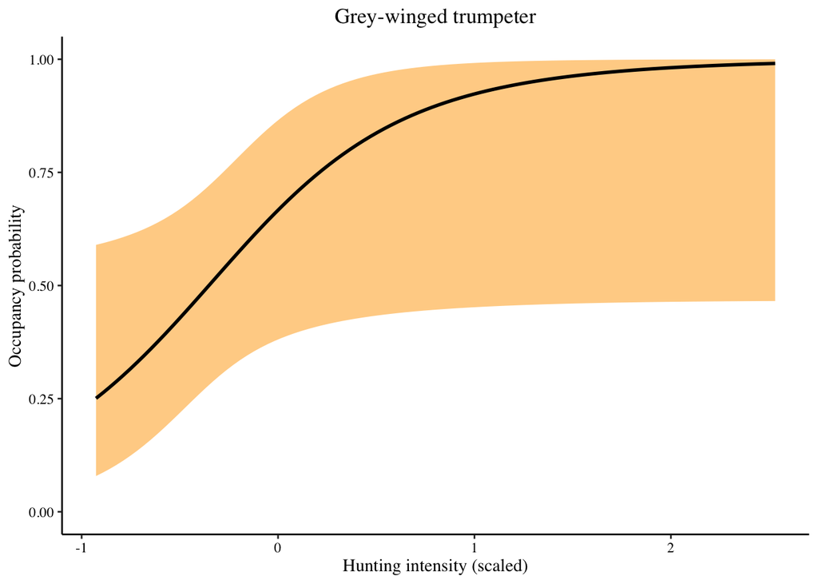

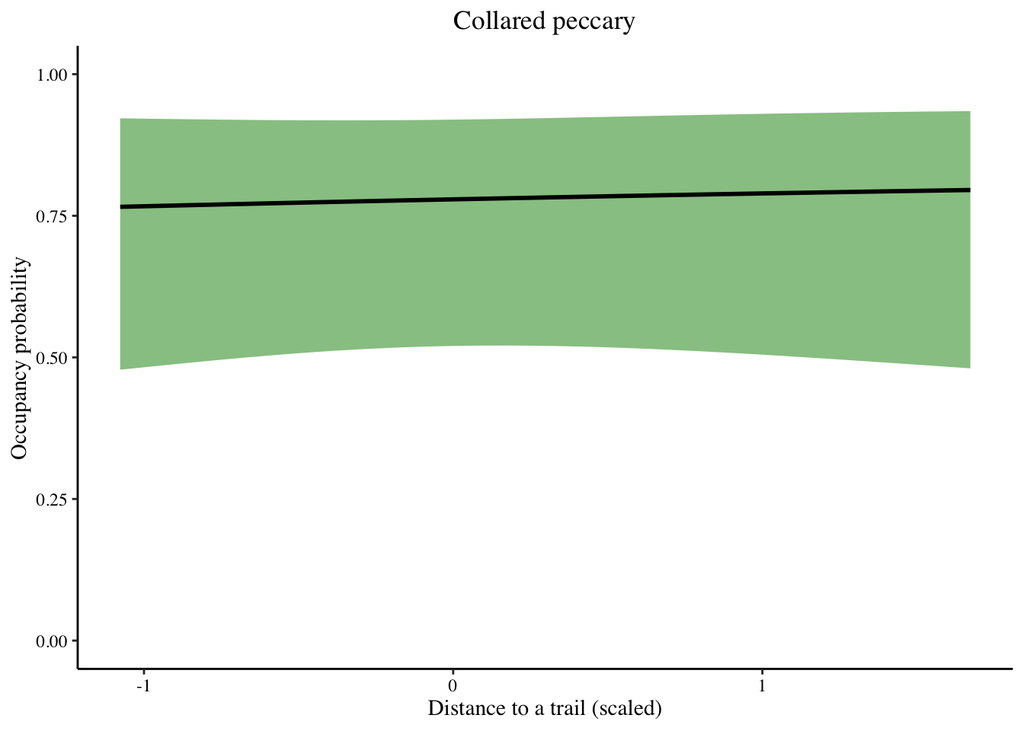

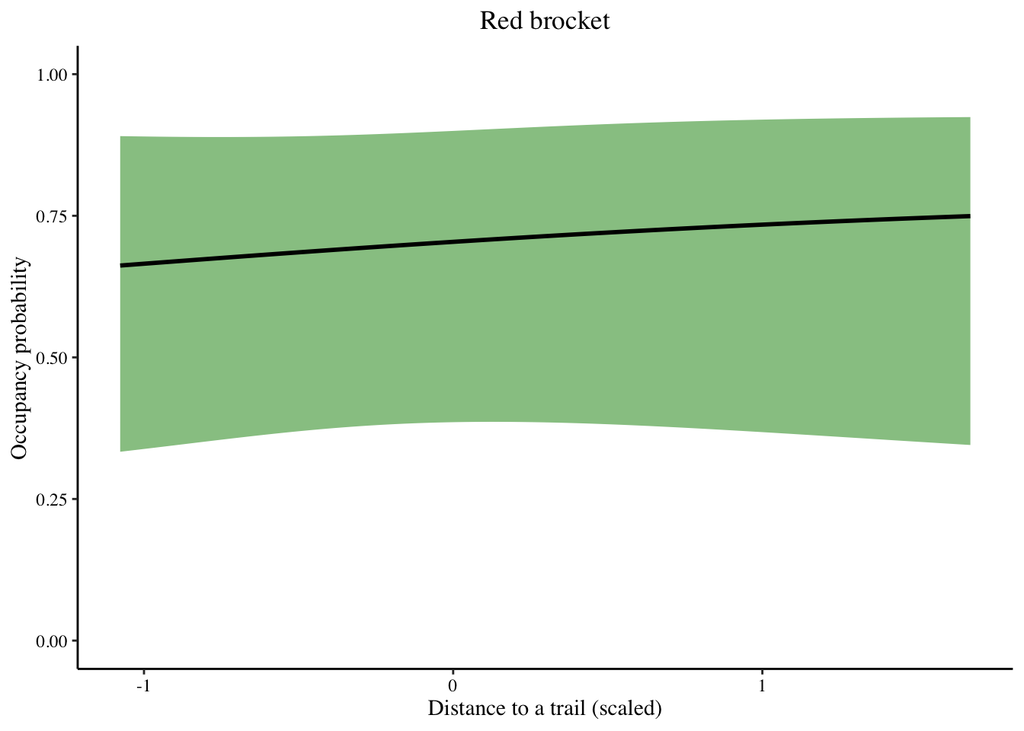

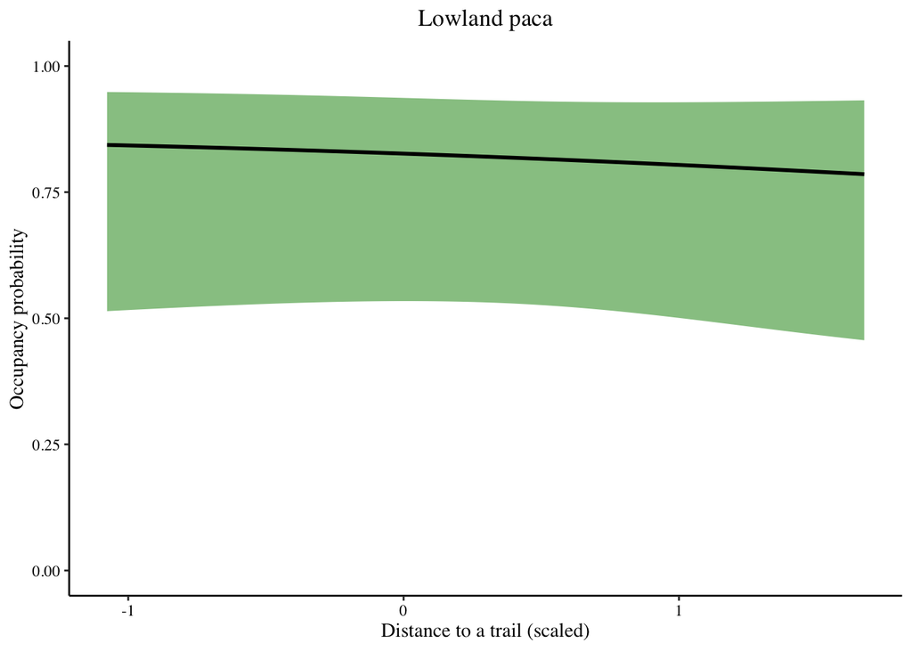

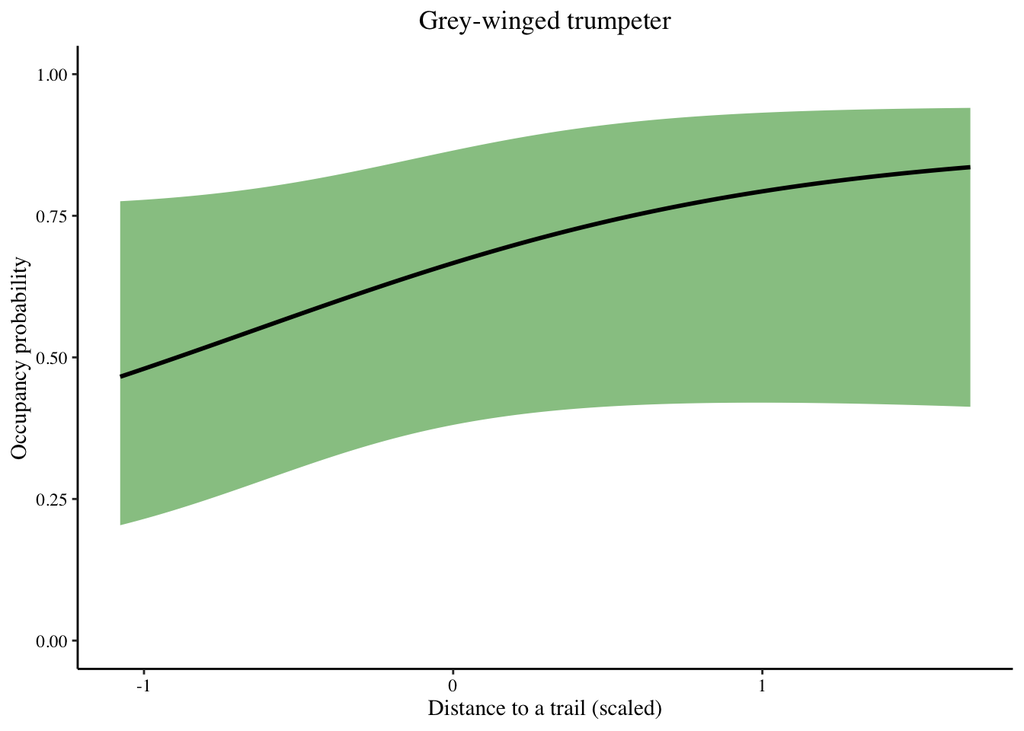

## Occupancy and detection estimates

Occupancy and detection are averaged across sites using actual covariate values as input.

### Sinangoe

Sinangoe occupancy and detection estimates

| Species | avgOccupancy | avgOccupancySE | avgDetection | avgDetectionSE |
| --- | --- | --- | --- | --- |
| Collared peccary | 0.5198679 | 0.1114989 | 0.0854902 | 0.0152023 |
| Red brocket | 0.8667594 | 0.0722374 | 0.1605056 | 0.0138197 |
| Lowland paca | 0.7285123 | 0.0918352 | 0.9230655 | 0.0442927 |
| Grey-winged trumpeter | 0.5207976 | 0.1107963 | 0.1022458 | 0.0103941 |

### Zabalo

Zabalo occupancy and detection estimates

[output not shown]